# HW5

**Import Required Packages**

```r
library(readr)
library(dplyr)
library(ggplot2)
# used in test normal distribution of the data
# get the probabilty of second type error
library(nortest) # install.packages("nortest")
library(pwr) # install.packages("pwr")
```

# Task1

**Read the dataset then take a look to it’s variables.**

```r
dt <- read_delim("ab_clicks.csv","\t", escape_double = FALSE, trim_ws = TRUE)
View(dt)
# Different tags
unique(dt$Tag_name)
```

```
##  [1] "area"   "a"      "input"  "button" "span"   "p"      "div"
##  [8] "form"   "img"    "ul"     "li"     "object" "center" "strong"
## [15] "font"
```

```r
unique(dt$Version)
```

```
## [1] "Interact" "Connect"  "Learn"    "Help"     "Services"
```

**Plot total amount of click on each version**

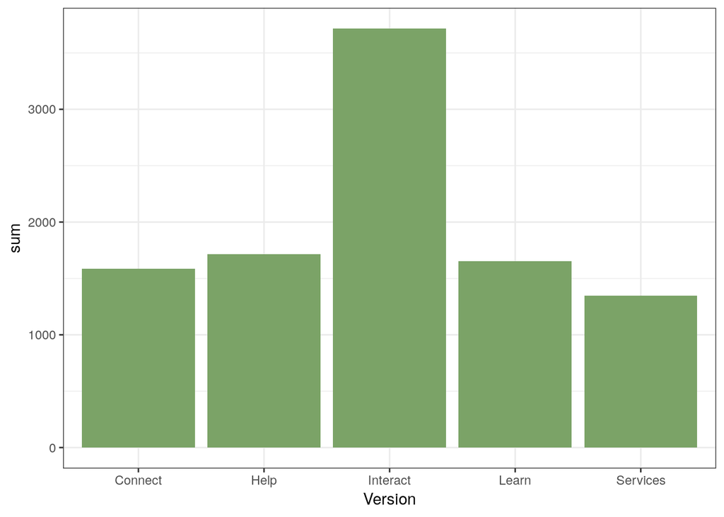

```r
dt %>%
  group_by(Version) %>%
  summarise(sum = sum(No_clicks)) %>%
  ggplot(aes(x=Version, y=sum)) +
  geom_histogram(stat = "identity", fill="#7ba367", bins = 30)+ theme_bw()
```

**take amount of the clicks on the button Interact at the different sites and plot it. From the plot we can see Interact has more clicks than the Learn version.**

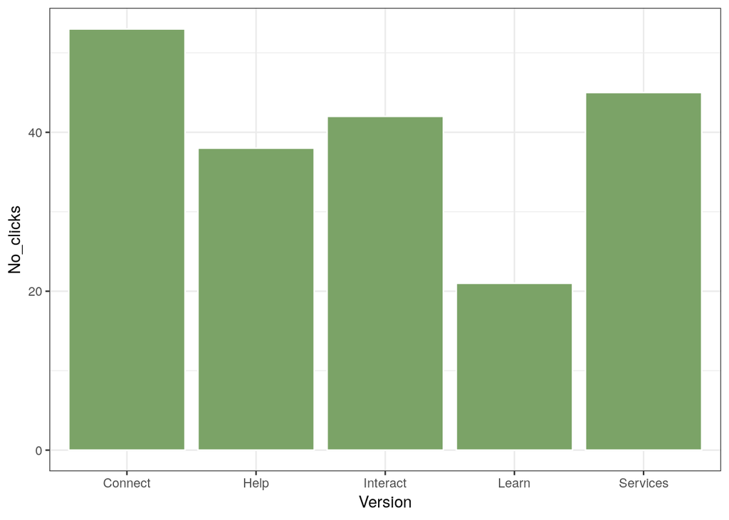

```r
btn_names <- c("INTERACT", "LEARN", "CONNECT", "HELP", "SERVICES")
btns <- dt %>%
  filter(Name %in% btn_names)
# plot
ggplot(btns, aes(x=Version, y=No_clicks)) +
  geom_histogram(stat = "identity" ,fill= "#7ba367", color="white", bins= 30) + theme_bw()
```

**Prepare data for caomparison between Interact and Learn version.**

```r
# remove text that we are not interested in
dt_cleaned <- filter(dt, Tag_name !='area')

# here we need to chose only one from "learn, help, service" and compare it interact
# remove other version from our dataset
dt_interact_learn <- filter(dt_cleaned, Version %in% c("Interact", "Learn"))

# run T-test, we are looking for the version by numpber of clicks
t.test(No_clicks ~ Version, data=dt_interact_learn)
```

```
##
##  Welch Two Sample t-test
##
## data:  No_clicks by Version
## t = 0.54206, df = 121.51, p-value = 0.5888
## alternative hypothesis: true difference in means is not equal to 0
## 95 percent confidence interval:
##  -26.28528  46.10736
## sample estimates:
## mean in group Interact    mean in group Learn
##               35.63235               25.72131
```

**(Null hypothesis)H0: there is no difference between version interact and learn If we accepted it that means we can use any version either interact or learn.**

**To decide either we should accept or reject the null hypothesis we should look at P-value if it’s below threshold (0.05) then we reject the null hypothesis. We can see that the P-value is greater than the threshold then we will accept the H0 and therefore there is no difference between the interact or learn version.**

**the value of t calculated during the test and df is the degree of freedom. Also, we are confident to accept the H0 by 95%.**

**We need to test if our data is normally distributed or not by plotting.**

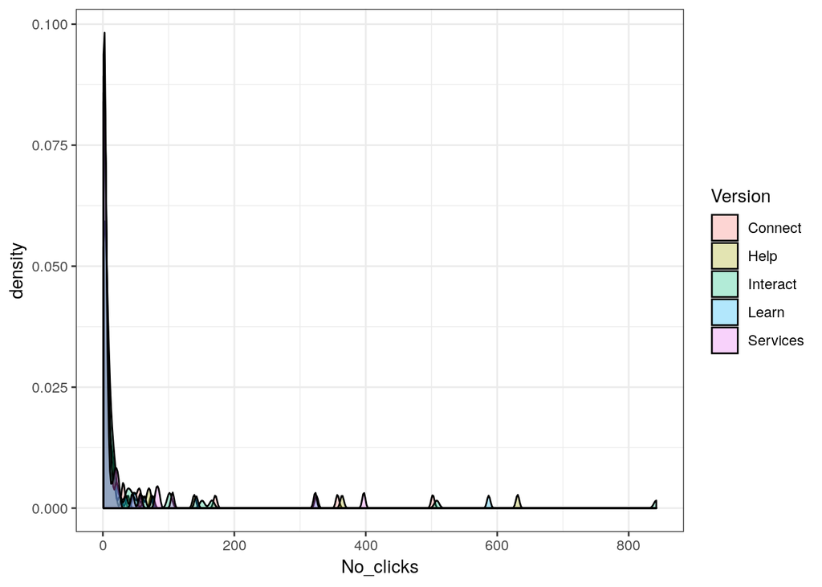

```r
ggplot(dt_cleaned, aes(x=No_clicks, fill=Version)) + geom_density(alpha=0.3) + theme_bw()
```

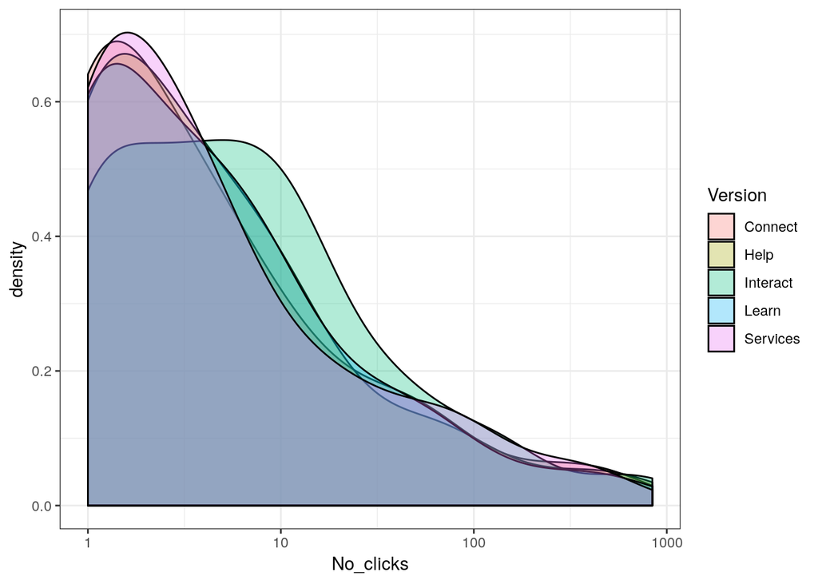

```r
ggplot(dt_cleaned, aes(x=No_clicks, fill=Version)) + geom_density(alpha=0.3) + theme_bw() + scale_x_log10()
```

**From the above plot, we can see that our data is not normally distributed..**

**Below is another method to check the normality of our data. If our data is normally distributed below curve should be line with 45-degree angle**

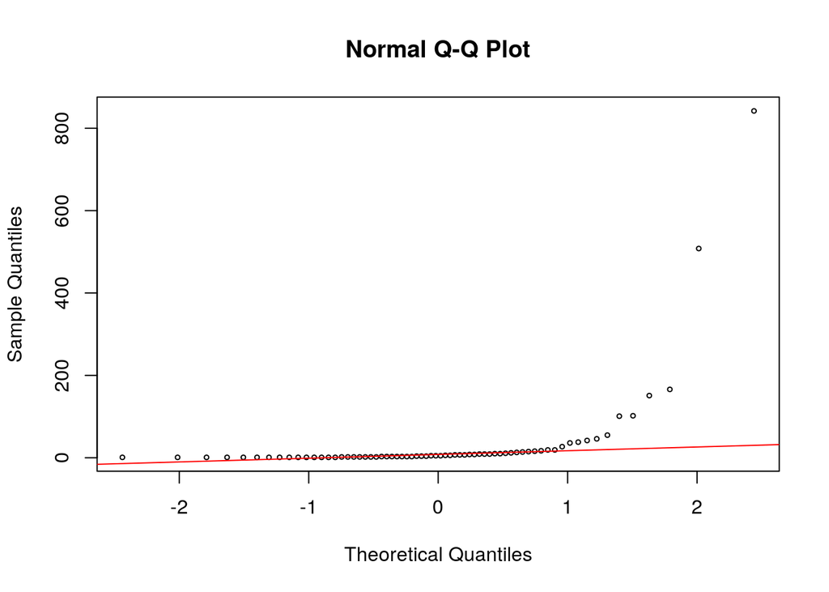

```r
#nortest
qqnorm(filter(dt_cleaned, Version=='Interact')$No_clicks, cex=0.5)
qqline(filter(dt_cleaned, Version=='Interact')$No_clicks, col = 2)
```

**We can use Wilcoxon test for normality instead of t-test (as the Normality assumption is not fulfilled), or we can use transform No_clicks to log10 and we can find that both tests get the same results..**

```r
wilcox.test(No_clicks ~ Version, data=dt_interact_learn)
```

```
##
##  Wilcoxon rank sum test with continuity correction
##
## data:  No_clicks by Version
## W = 2381, p-value = 0.1435
## alternative hypothesis: true location shift is not equal to 0
```

```r
dt_interact_learn <- dt_interact_learn %>%
  mutate(log_clicks = log10(No_clicks))

wilcox.test(log_clicks ~ Version, data=dt_interact_learn) # same result
```

```
##
##  Wilcoxon rank sum test with continuity correction
##
## data:  log_clicks by Version
## W = 2381, p-value = 0.1435
## alternative hypothesis: true location shift is not equal to 0
```

```r
pwr.t.test(d = 0.2, power=0.8)
```

```
##
##      Two-sample t test power calculation
##
##               n = 393.4057
##               d = 0.2
##       sig.level = 0.05
##           power = 0.8
##     alternative = two.sided
##
## NOTE: n is number in *each* group
```

**Using Different type of test: “Test of proportion”.**

```r
total_clicks <- group_by(dt, Version) %>%
  summarise(total = sum(No_clicks))   # total number of clicks
dt_button <- filter(dt, Name %in% c("SERVICES", "HELP", "LEARN","CONNECT", "INTERACT")) %>%
  # choose only areas we focus
  left_join(total_clicks, by = "Version")  %>%
  mutate(proportions = No_clicks/total)# combine
dt_button
```

```
## # A tibble: 5 x 8
##   Element_ID Tag_name Name     No_clicks Visible Version  total proportions
##        <dbl> <chr>    <chr>        <dbl> <lgl>   <chr>    <dbl>       <dbl>
## 1         87 a        INTERACT        42 TRUE    Interact  3714      0.0113
## 2         92 a        CONNECT         53 TRUE    Connect   1587      0.0334
## 3         87 a        LEARN           21 TRUE    Learn     1652      0.0127
## 4         92 a        HELP            38 TRUE    Help      1717      0.0221
## 5         87 a        SERVICES        45 TRUE    Services  1348      0.0334
```

**Let’s take what we are interested in “Interact” and “Learn”“**

```r
prop.test(x=dt_button$No_clicks[c(1,3)], n=dt_button$total[c(1,3)]) #n: total amounts of the clicks
```

```
##
##  2-sample test for equality of proportions with continuity
##  correction
##
## data:  dt_button$No_clicks[c(1, 3)] out of dt_button$total[c(1, 3)]
## X-squared = 0.091962, df = 1, p-value = 0.7617
## alternative hypothesis: two.sided
## 95 percent confidence interval:
##  -0.008224008  0.005417404
## sample estimates:
##     prop 1     prop 2
## 0.01130856 0.01271186
```

**Here the P-Value is greater than the threshold(0.05) so we will accept the null hypothesis.**

**Calculate the power of the proportion test:**

```r
power.prop.test(n=dt_button$total[c(1,3)], p1=0.01130856, p2=0.01271186)
```

```
##
##      Two-sample comparison of proportions power calculation
##
##               n = 3714, 1652
##              p1 = 0.01130856
##              p2 = 0.01271186
##       sig.level = 0.05
##           power = 0.08003294, 0.05594535
##     alternative = two.sided
##
## NOTE: n is number in *each* group
```

**n: The total number of the clicks for the two options “Interact= 3714” and “Learn= 1652”. We can see also the power of the test is not that much large to be confident with this test.**

**Based on this proportion test the idea of change interact with learn is not correct we accept the null hypothesis**

```r
pwr.2p2n.test(h=0.1, power=0.8, n1=3714)
```

```
##
##      difference of proportion power calculation for binomial distribution (arcsine transformation)
##
##               h = 0.1
##              n1 = 3714
##              n2 = 995.2043
##       sig.level = 0.05
##           power = 0.8
##     alternative = two.sided
##
## NOTE: different sample sizes
```

**The power param signifies the prob of the second type error of your data, we assume that no type error with 80% probability. Sig.level: indicates the probability of type one error.**

# concluded results:

We performed two different tests using t-test, and proportion test. Using the tests results we will accept the null hypothesis, since the P-Value is greater than the threshold.

# Task2:

**1. Read about Multiple comparison problem.** Multiple comparisons arise when a statistical analysis involves multiple simultaneous statistical tests, each of which has a potential to produce a “discovery”. A stated confidence level generally applies only to each test considered individually, but often it is desirable to have a confidence level for the whole family of simultaneous tests because as the number of comparisons increases, it becomes more likely that the groups being compared will appear to differ in terms of at least one attribute. Our confidence that a result will generalize to independent data should generally be weaker if it is observed as part of an analysis that involves multiple comparisons, rather than an analysis that involves only a single comparison.

**2. 1000 different tests related to landing page comparisons of different versions and collected p-values in a vector to see where number of clicks are statistically significant:**

```r
pwr.t.test(alternative = "two.sided", power=0.8,d = 0.2)
```

```
##
##      Two-sample t test power calculation
##
##               n = 393.4057
##               d = 0.2
##       sig.level = 0.05
##           power = 0.8
##     alternative = two.sided
##
## NOTE: n is number in *each* group
```

```r
set.seed(3583)
p_values <- abs(rnorm(1000, 0, sd=0.2))
p_values <- ifelse(p_values>1, 0, p_values)
p_values
```

[output not shown]

[output cut: 185 more lines]

**3. How many tests are statistically significant (under α=0.05)**

```r
count = 0

for(i in 1:length(p_values)) {
  if(p_values[i] < 0.05)
  {
    count = count + 1
  }
}
cat("number of tests that are statistically significant are  ", count)
```

```
## number of tests that are statistically significant are   203
```

**4. Use p.adjust function to perform corrections for multiple comparisons. Choose 2 different methods.**

**Compare number of significant tests after the corrections. What has changed?** this method is used for adjusting the p-values to account for the multiple comparisons issue it returns the correction adjastments for the p values. The FDR method stands for false discovery rate that interrpret the rate of type one errors in the null hypothesis testing when having multiple comparisons.

Both bonferroni, fdr are error rate controlling procedures

The result showed that after using the adjusted P-values, it lead to a very high rate of false negatives because bonferroni has a lack of power for the correction.

The number of significant tests after corrections is zero, while before using adjust function it was 203.

```r
# 'arg' should be one of "holm", "hochberg", "hommel", "bonferroni", "BH", "BY", "fdr", "none"

bonferroniValues <- p.adjust(p_values, method="bonferroni", n =length(p_values))
print(bonferroniValues)
```

[output not shown]

[output cut: 152 more lines]

```r
count = 0

for(i in 1:length(bonferroniValues)) {
  if(bonferroniValues[i] < 0.05)
  {
    count = count + 1
  }
}
cat("number of tests for bonferroni that are statistically significant are  ", count)
```

```
## number of tests for bonferroni that are statistically significant are   0
```

```r
fdrValues <- p.adjust(p_values, method="fdr", n = length(p_values))
print(fdrValues)
```

[output not shown]

[output cut: 152 more lines]

```r
count = 0
for(i in 1:length(fdrValues)) {
  if(fdrValues[i] < 0.05)
  {
    count = count + 1
  }
}
cat("number of fdr tests that are statistically significant are  ", count)
```

```
## number of fdr tests that are statistically significant are   0
```

# Task. 3.

**1. Check whether the difference in conversion rate is significant. Calculate the number of instances to collect to achieve the power of the test (power=0.8). What can you claim based on those results?**

```r
library(readr)
dataset <- read_csv("conversion.csv")
View(dataset)
```

the ouutput of the prob.test function is p-value = 0.2458 which is not significant also the proportions are: prop 1 prop 2 0.1038462 0.1288462 we will use those proportions for the power.prop.test to get the number of samples needed.

we need to claim that in order to have power = 0.8, we need to have number of samples n = 2576.219. also the significance level is 0.05. we also used ES.h to calculate the effect size for the pwr.t.test function.

```r
myn <- as.matrix(dataset[,0:2])
prop.test(x=myn)
```

```
##
##  2-sample test for equality of proportions with continuity
##  correction
##
## data:  myn
## X-squared = 1.3468, df = 1, p-value = 0.2458
## alternative hypothesis: two.sided
## 95 percent confidence interval:
##  -0.06586777  0.01586777
## sample estimates:
##    prop 1    prop 2
## 0.1038462 0.1288462
```

```r
power.prop.test(n=dataset$converted[c(1,2)], p1=0.1038462, p2=0.1288462  )
```

```
##
##      Two-sample comparison of proportions power calculation
##
##               n = 54, 67
##              p1 = 0.1038462
##              p2 = 0.1288462
##       sig.level = 0.05
##           power = 0.05985319, 0.06554307
##     alternative = two.sided
##
## NOTE: n is number in *each* group
```

```r
h <- ES.h(0.1038462, 0.1288462)
#to find the sample size needed
pwr.t.test(d= h,power = 0.8,type="two.sample",alternative="two.sided")
```

```
##
##      Two-sample t test power calculation
##
##               n = 2576.219
##               d = 0.07807426
##       sig.level = 0.05
##           power = 0.8
##     alternative = two.sided
##
## NOTE: n is number in *each* group
```

```r
pwr.2p2n.test( h = h, sig.level = 0.05, n1 = 54, n2=67)
```

```
##
##      difference of proportion power calculation for binomial distribution (arcsine transformation)
##
##               h = 0.07807426
##              n1 = 54
##              n2 = 67
##       sig.level = 0.05
##           power = 0.07112873
##     alternative = two.sided
##
## NOTE: different sample sizes
```

**2. Are the result significant? What is the power of this test? Did the ratios between the first and the second experiments change? What is the lesson here?**

the P-value of the second experiment is soo small while The power of this test is 0.2784212 which is much better than the previous test.

The higher the power value means that that we need to increase the confidence that we have in the result. so it means that we need a larger sample size.

The propabilities (Ratios) changed a little bit and the power for the second exprement is more than the first.

the lesson learnet is that for having higher power value we need smaller value of sig_level means that we need to increase the confidence that we have in the result. so it means that we need a larger sample size.

Also we need more number of observations to have more confidence level.

```r
dataset2 <- read_csv("conversion2.csv")
View(dataset2)
```

```r
prop.test(x=dataset2$converted[c(1,2)], n=dataset2$total[c(1,2)])
```

```
##
##  2-sample test for equality of proportions with continuity
##  correction
##
## data:  dataset2$converted[c(1, 2)] out of dataset2$total[c(1, 2)]
## X-squared = 15.981, df = 1, p-value = 6.397e-05
## alternative hypothesis: two.sided
## 95 percent confidence interval:
##  -0.03791853 -0.01285070
## sample estimates:
##    prop 1    prop 2
## 0.1042308 0.1296154
```

```r
# power.prop.test(n=dataset2$converted[c(1,2)], p1=0.1042308, p2=0.1296154  )
h <- ES.h(0.1042308, 0.1296154)
# pwr.t.test(d= h,power = 0.8,type="two.sample",alternative="two.sided")

pwr.2p2n.test(h = h, n1=542, n2 = 674, sig.level = 0.05)
```

```
##
##      difference of proportion power calculation for binomial distribution (arcsine transformation)
##
##               h = 0.07910757
##              n1 = 542
##              n2 = 674
##       sig.level = 0.05
##           power = 0.2784212
##     alternative = two.sided
##
## NOTE: different sample sizes
```